# Illustration of MEFISTO on simulated data with a temporal covariate

Britta Velten

9 October 2020

#### Package

MOFA 1.4.0

# Contents

```r
library(MOFA2)
library(tidyverse)
library(pheatmap)
```

# 1 Temporal data: Simulate an example data set

To illustrate the SMOFA functionality of MOFA2 we simulate a small example data set with 4 different views and one covariates defining a timeline using `make_example_data`. The simulation is based on 4 factors, two of which vary smoothly along the covariate (with different lengthscales) and two are independent of the covariate. To mimic a situation where we only have incomplete data on the samples we mask 50% of the samples on average per view.

```r
set.seed(2020)

# set number of views and samples
N <- 200
time <- seq(0,1,length.out = N)
M <- 4

# generate example data
dd <- make_example_data(sample_cov = time, n_samples = N, n_factors = 4, n_features = 200, n_views = M, lscales = c(0.5, 0.2, 0, 0))
```

Let’s have a look at the simulated latent temporal processes, which we want to recover:

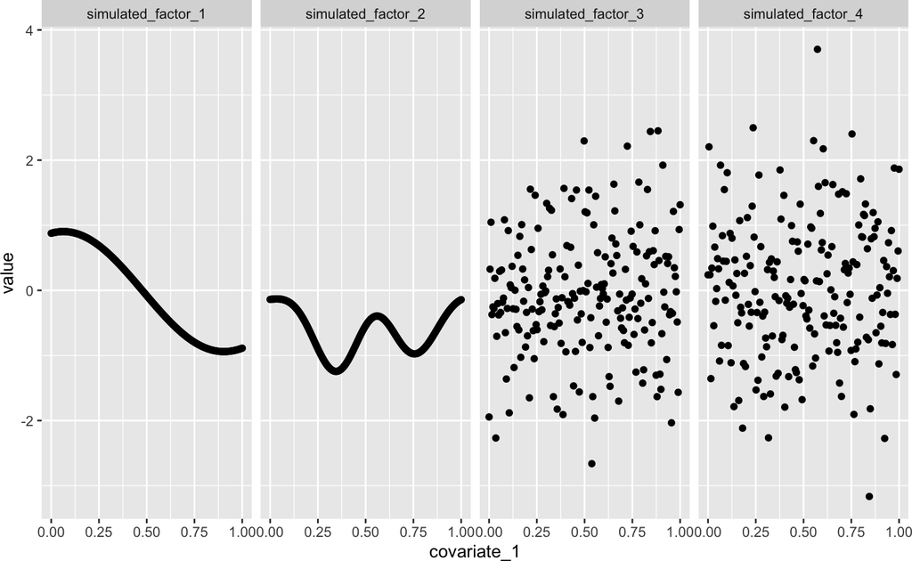

```r
df <- data.frame(dd$Z, t(dd$sample_cov))
df <- gather(df, key = "factor", value = "value", starts_with("simulated_factor"))
ggplot(df, aes(x =covariate_1, y = value)) + geom_point() + facet_grid(~factor)
```

# 2 MEFISTO framework

Using the MEFISTO framework is very similar to using MOFA2. In addition to the omics data, however, we now additionally specify the time points for each sample. If you are not familiar with the MOFA2 framework, it might be helpful to have a look at MOFA2 tutorials first.

## 2.1 Create a MOFA object with covariates

To create the MOFA object we need to specify the training data and the covariates for pattern detection and inference of smooth factors. Here, `sample_cov` is a matrix with samples in columns and one row containing the timepoints. The sample order must match the order in data columns. Alternatively, a data frame can be provided containing one `sample` columns with samples names matching the sample names in the data.

First, we start by creating a standard MOFA model and specify model (and training options) such as the number of factors.

```r
sm <- create_mofa(data = dd$data)
```

```
## Creating MOFA object from a list of matrices (features as rows, sample as columns)...
```

```
## No groups provided as argument... we assume that all samples are coming from the same group.
```

Now, we can add the additional temporal covariate, that we want to use for training and specify that we want to use a smooth modeling framework by specifying `smooth_options` when preparing the object. For this you can just use the default options, unless you want to make use of advanced options such as alignment across groups.

```r
sm <- set_covariates(sm, dd$sample_cov)
sm
```

```
## Untrained MEFISTO model with the following characteristics:
##  Number of views: 4
##  Views names: view_1 view_2 view_3 view_4
##  Number of features (per view): 200 200 200 200
##  Number of groups: 1
##  Groups names: group1
##  Number of samples (per group): 200
##  Number of covariates per sample: 1
##
```

We now successfully created a MOFA object that contains 4 views, 1 group and 1 covariates giving the time points for each sample.

## 2.2 Prepare a MOFA object

Before training, we can specify various options for the model, the training and the data preprocessing. If no options are specified, the model will use the default options. See also `get_default_data_options`, `get_default_model_options` and `get_default_training_options` to have a look at the defaults and change them where required. For illustration, we only use a small number of iterations.

Importantly, to activate the use of the covariate for a functional decomposition (MEFISTO) we no additionally to the standard MOFA options need to specify `smooth_options`. For this you can just use the default options (`get_default_smooth_options`), unless you want to make use of advanced options such as alignment across groups.

```r
model_opts <- get_default_model_options(sm)
model_opts$num_factors <- 4

train_opts <- get_default_training_options(sm)
train_opts$maxiter <- 100

smooth_opts <- get_default_smooth_options(sm)

sm <- prepare_mofa(sm, model_options = model_opts, smooth_options = smooth_opts, training_options = train_opts)
```

## 2.3 Run MOFA

Now, the MOFA object is ready for training. Using `run_mofa` we can fit the model, which is saves in the file specified as `outfile`. If none is specified the output is only saved in a temporary location

```r
sm <- run_mofa(sm)
```

## 2.4 Down-stream analysis

### 2.4.1 Variance explained per factor

Using `plot_variance_explained` we can explore which factor is active in which view. `plot_factor_cor` shows us whether the factors are correlated.

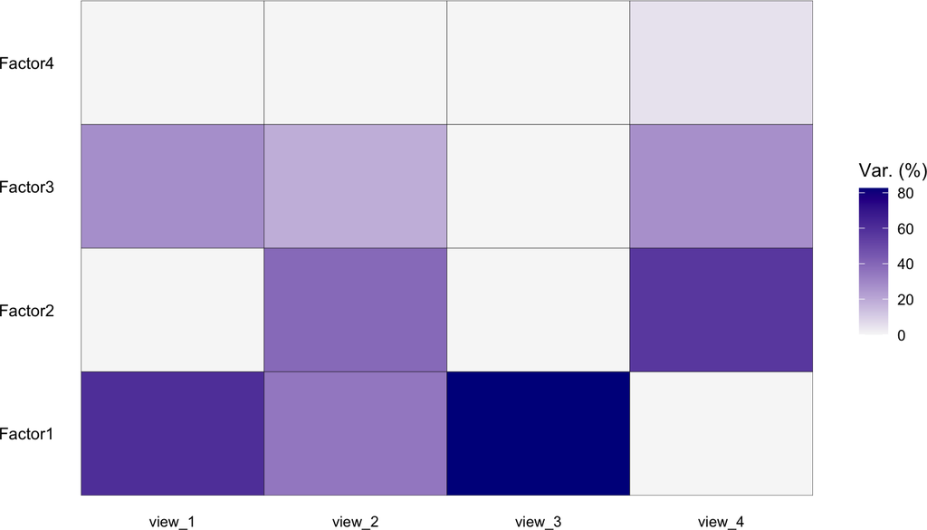

```r
plot_variance_explained(sm)
```

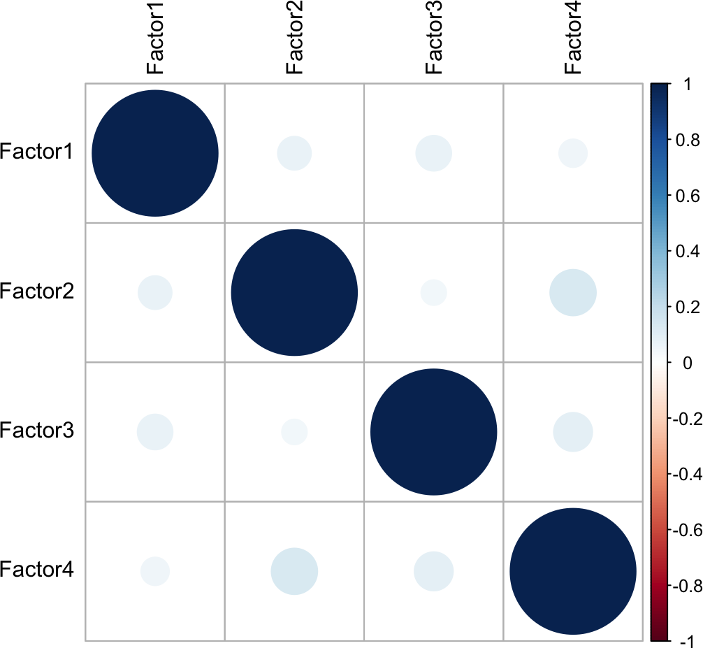

```r
r <- plot_factor_cor(sm)
```

### 2.4.2 Relate factors to the covariate

The MOFA model has learnt paramerers for each factor that tell us how smoothly the factor varys along the covariate. A scale of 0 means that the factor captures variation independent of time, a value close to 1 tells us that this factor varys very smoothly along time. In this example, we find two factors that are non-smooth and two smooth factor. Using `plot_factors_vs_cov` we can plot the factors along time, where we can distinguish smooth and non smooth variation along time.

```r
get_scales(sm)
```

```
##    Factor1    Factor2    Factor3    Factor4
## 0.00000000 0.01197979 0.99892554 0.99524585
```

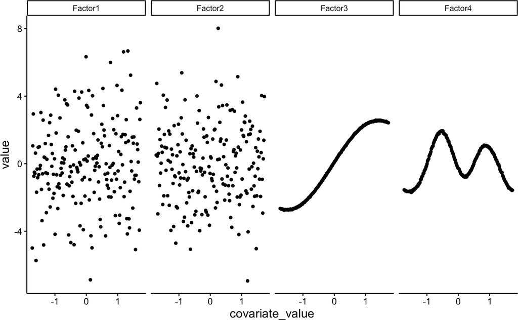

```r
plot_factors_vs_cov(sm)
```

We can compare this to the factors that were simulated above and find that the model recaptured the two smooth as well as two stochastic patterns in time. Note that factors are invariant to the sign, e.g. factor 4 is the negative of the simulated factor but we can simply multiply the factors and its weights by -1 to obtain exactly the simulated factor.

### 2.4.3 Exploration of weights

As with MOFA+ we can now look deeper into the meaning of these factors by exploring the weights or performing feature set enrichment analysis.

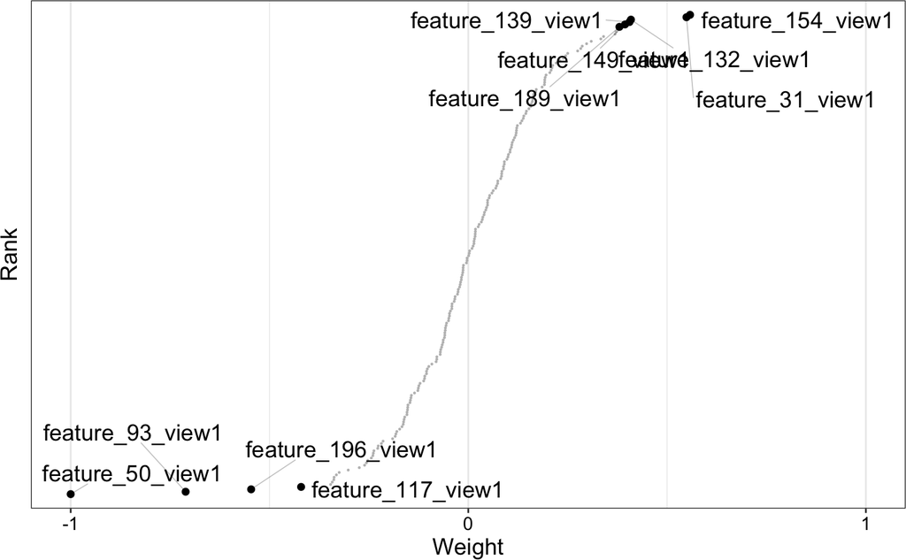

```r
plot_weights(sm, factors = 4, view = 1)
```

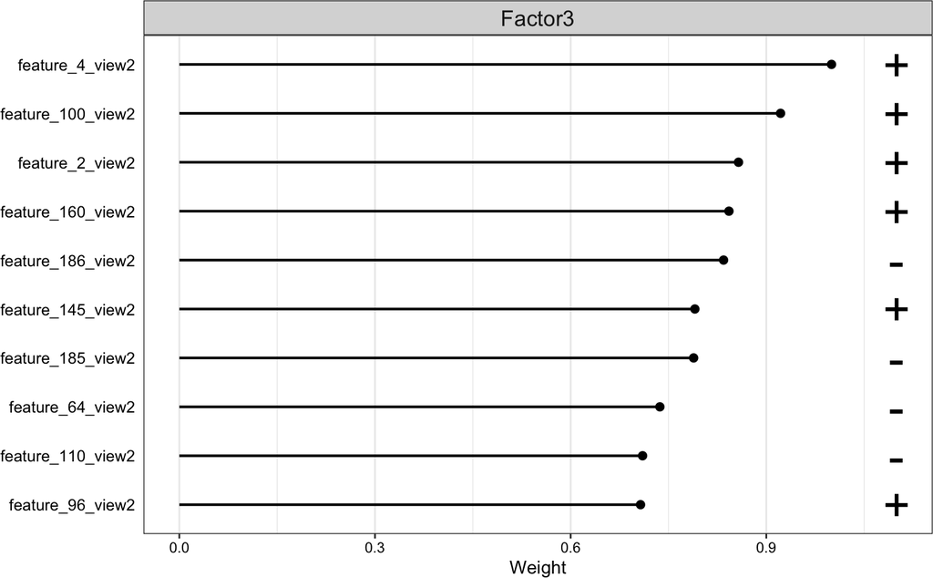

```r
plot_top_weights(sm, factors = 3, view = 2)
```